# Лабораторна робота №3. Аналіз складності алгоритмів. Алгоритми сортування

Виконав: П'ятибрат Д.С.

## Мета

Засвоїти технологію реалізації алгоритмів сортування засобами Python та оцінку їх складності.

## Хід роботи

**Завдання:**

1. Виконати теоретичні розрахунки асимптотичної складності алгоритмів сортування методами вставлення та бульбашки.
2. Реалізувати на Python алгоритми сортування.
3. Дослідити реальний час виконання обох алгоритмів та побудувати графіки залежностей $T_{insert}(n)$ та $T_{bubble}(n)$.

**Виконання:** Сортування вставленням має асимптотичну складність $O(n^2)$, оскільки для кожного елемента масиву може виконуватися до $n$ порівнянь і зсувів. Сортування бульбашкою також має складність $O(n^2)$, тому що використовує два вкладені цикли, які проходять по всьому масиву.

```python
import time
import random
import matplotlib.pyplot as plt
```

```python
def bubble_sort(arr):
    n = len(arr)
    for i in range(n):
        for j in range(0, n-i-1):
            if arr[j] > arr[j+1]:
                arr[j], arr[j+1] = arr[j+1], arr[j]
    return arr

def insertion_sort(arr):
    for i in range(1, len(arr)):
        key = arr[i]
        j = i-1
        while j >= 0 and key < arr[j]:
            arr[j+1] = arr[j]
            j -= 1
        arr[j+1] = key
    return arr
```

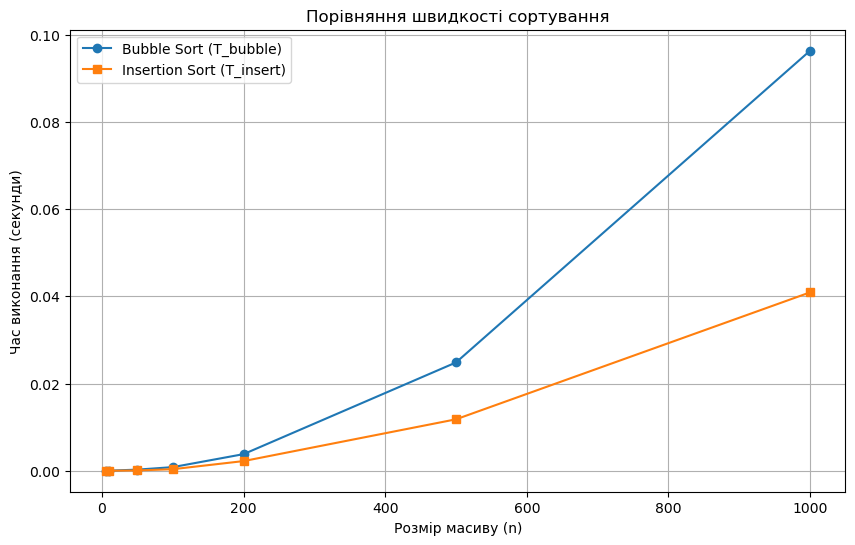

```python
n_values = [5, 10, 50, 100, 200, 500, 1000]
bubble_times = []
insert_times = []

for n in n_values:
    test_arr = [random.randint(0, 10000) for _ in range(n)]


    start = time.perf_counter()
    bubble_sort(test_arr.copy())
    bubble_times.append(time.perf_counter() - start)


    start = time.perf_counter()
    insertion_sort(test_arr.copy())
    insert_times.append(time.perf_counter() - start)


plt.figure(figsize=(10, 6))
plt.plot(n_values, bubble_times, label='Bubble Sort (T_bubble)', marker='o')
plt.plot(n_values, insert_times, label='Insertion Sort (T_insert)', marker='s')
plt.xlabel('Розмір масиву (n)')
plt.ylabel('Час виконання (секунди)')
plt.legend()
plt.grid(True)
plt.title('Порівняння швидкості сортування')
plt.show()
```

## Висновок

Обидва алгоритми мають складність $O(n^2)$, але на практиці сортування вставленням працює швидше за бульбашкове сортування. Зі збільшенням розміру масиву час виконання значно зростає.

## Контрольні питання

1. **Що таке O-нотація і чим вона відрізняється від $\Omega$-нотації?** O-нотація описує верхню межу складності алгоритму (найгірший випадок). $\Omega$-нотація — нижню межу (найкращий випадок).
2. **Яку часову складність має алгоритм сортування методом вставлення за найсприятливіших умов?** У найкращому випадку масив вже відсортований, тоді алгоритм виконує лише лінійний прохід. Складність: $O(n)$.
3. **Визначення ефективного алгоритму** Це алгоритм, який вирішує задачу з мінімальними витратами ресурсів (часу та пам'яті).
4. **Поняття головного параметра (розміру) задачі** Це величина, яка визначає вхідні дані алгоритму і впливає на його складність (найчастіше це кількість елементів $n$).
5. **Асимптотична складність функції $F(N) = N^3 + 7N^2 - 14N$** Це $O(N^3)$, оскільки при великих значеннях $N$ домінуючим є доданок з найвищим степенем.